# Die Hard 1.1024.0: Backward compatibility of a search engine with persistent IDs

deRSE19 - Conference for Research Software Engineers in Germany, 2019-06-04

Thomas Krause (Humboldt-Universität zu Berlin)

Stephan Druskat (Friedrich Schiller University Jena, German Aerospace Center (DLR))

# Background

## The Hexatomic project

“A minimal infrastructure for the **sustainable** provision of extensible *multi-layer annotation software for linguistic corpora*”

- Funded under the call “Research Software Sustainability” issued by DFG under grant number GA 1288/11-1
- Runs from October 2018 until September 2021
- Thomas Krause: computer scientist who slipped into linguistics
- Stephan Druskat: English M.A. turned software developer & computer scientist
- Both: Research Software Engineers

## ANNIS and its query language

Web browser-based search and visualization architecture for *linguistic corpora* with diverse types of *annotation*. Part of the corpus-tools.org collection of tools for linguists. (Druskat et al. 2016)

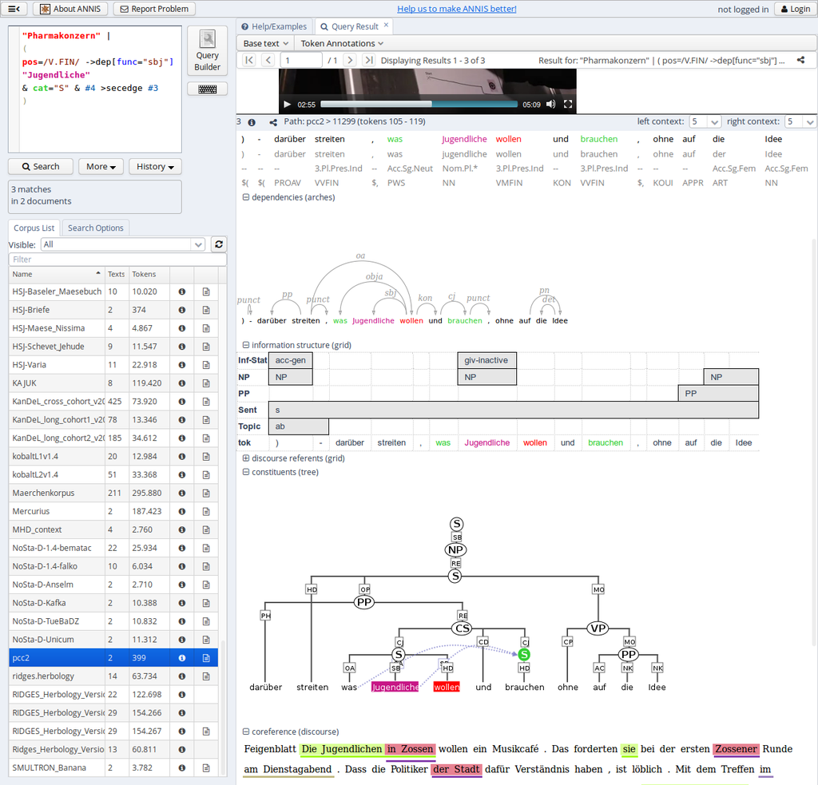

- Annotations are structured information added to text represented as a **graph with labels**
- Used by expert users (linguists) to **find and analyze linguistic phenomena**
- ANNIS allows finding annotations and *combinations* of annotations with its domain specific query language AQL
- AQL describes **nodes labels** and **joins them with operators**, which constrain the relation of the nodes in the graph

## Semantic Versioning

- Popularized by [semver.org](https://semver.org/) (Preston-Werner n.d.)
- Explicit statement about compatibility between versions of API
- *MAJOR*.*MINOR*.*PATCH*
  - Only bug fixes when *PATCH* changes, API does not change
  - Additions to API marked as increase of *MINOR*
  - Removal and non-backward compatible changes need an increase in *MAJOR*

Some open questions:

- What is part of the API in a complex piece of software with multiple components?
  - REST API?
  - Query language?
  - Data exchange format?
  - User Interface?
- **Do we want to backward-compatible forever? Is there a “1.0 release anxiety”?**

## Persistent identifiers (PIDs)

What do I mean exactly when I refer to the “ANNIS software”?

http://corpus-tools.org/annis? https://github.com/thomaskrause/ANNIS/? https://github.com/korpling/ANNIS/? Version 3.5.1? Version 4?

I can reference a specific software by a Digital object identifier (DOI):

- In general: resolving an identifier to a resource (digital or not)
- **Should never change**, i.e., you can print it in a book!
- Several systems exist, e.g. DOI, handle.net, …

Some open questions:

- If a digital resource moves, who updates the reference?
- Who provides and funds the infrastructure?

# Achieving backward compatibility in ANNIS 4

## What is the digital object defined by ANNIS citation links?

- ANNIS allows generating short links to query results and single matches, e.g., https://korpling.org/annis3/?id=813c3146-2d10-4d0c-8a1f-1b5efc3c051a

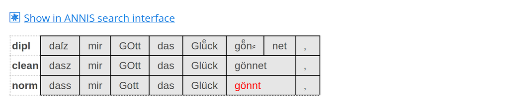

- Glorified URL shortener: expands to a longer URL encoding the match and the actual query paramters, e.g., https://korpling.org/annis3/#_q=bm9ybT0vZ8O2bm50Lw&_c=UklER0VTX[…]
- Query is executed each time the link is opened, no result identifiers are saved

## Backward compatibility

Problem:

- ANNIS 3: AQL queries are mapped to SQL queries and executed by PostgreSQL
- ANNIS 4: custom in-memory graph-based search engine written in Rust, which directly executes AQL (Krause 2019)

All old reference links should still work.

Users literally printed these links in books.

Solution 1: Keep the old software running forever (in parallel to the new one)

**Solution 2: Make sure that each query that has been referenced, produces the same result in ANNIS 4 as in ANNIS 3**

- Execute each referenced query on both ANNIS 3 and 4
- Compare the results
- If successful: Migrate the links to the new ANNIS 4 installation

## Query language incompatibility is a feature

- New version will remove some query language functions and fix bugs in the query execution
- Backward compatibility means supporting old features or even replicating these bugs
- We need a *quirks mode* emulating old behavior

Other examples:

- Internet Explorer
- Rust language “editions” for opting in into breaking-change features

“We can’t get rid of it because we have a commitment to not breaking users’ code. There will not be a Rust 2.0.” - Steve Klabnik (https://news.ycombinator.com/item?id=19638000)

[figure not shown]

# Selected problems from the migration process

## Formalized semantics of the data model and the query language

- In an ideal world a query language is formally defined like Datalog (Ceri, Gottlob, and Tanca 1989)
  - Based on predicate logic
  - Declaration of so-called facts and rules how to infer new facts
- All you need to restore a digital object would be the data and any implementation conforming to the specification

Real world: SQL

- SQL versions have been standardized (…, SQL-93, SQL:1999, SQL:2003, …)
- Various implementations (MySQL, PostgreSQL, Oracle, DB2, SQLite, …) with different support for the standard and vendor extensions
- AQL has only two implementations, but the first implementation inherited semantics of SQL and its implementation in PostgreSQL
- Problems of changing AQL implementations are similar to those in **migrating an application from one SQL implementation to another**

## Un-implemented functions of the query language

- A query language can accumulate a large number of features over time:
  - AQL has a large number of binary operators that describe the relation between two nodes in the graph
- Orthogonal features can be replaced
- Move implementation of such features to a specific code path that separate the “real” query language from the ugly parts (quirks mode)
- Check stored reference links to make it transparent if a query language feature has actually been used, and therefore needs emulation
- If too hard to implement:

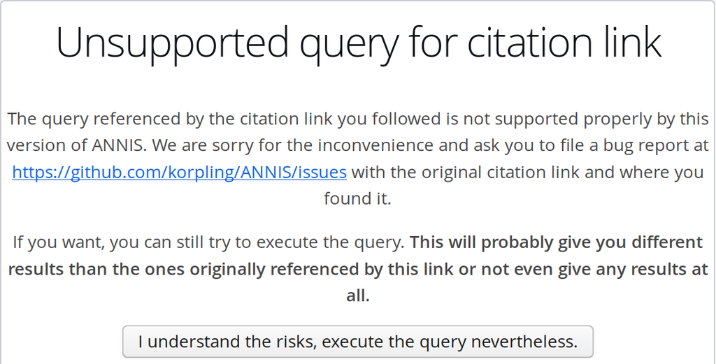

## Identifiers might change

- Each node in the graph has a URI and an internal identfier
- Matches are lists of URIs and additional names for the label the match refers to
- A match for a query is only the same if all URIs are the same

People will use weird names

- Spaces, slashes, umlauts, …
- Double percent-escaped characters
- Everything Unicode has to offer

[figure not shown]

https://github.com/minimaxir/big-list-of-naughty-strings

$→$ Importing data via IDs – and comparing them – is hard

## Regular expressions

Regular expressions are an important part of AQL for matching node and edge labels

```sql
-- PostgreSQL
SELECT * FROM t WHERE a ~ 'val.*';
-- MySQL
SELECT * FROM t WHERE a REGEXP 'val.*';
```

- Syntax varies from each implementation, even if „supporting POSIX“
- Regular expression engines often allow a search for non-regular expressions, such as backreferences and other extensions: some implementations trade features for speed (e.g RE2 from Google)
- “Power users“ will use all regular features available, even if never officially documented

## String ordering/collation

For query results, the order of the results is important, e.g. when refering to matches $→$ ANNIS 4 reference migration checks order of the matches as well

What is the result of the following SQL query?

```sql
SELECT '_' < '-';
```

- Depends on your localization! `LANG=C` != `LANG=en_US.UTF-8` != `LANG=de_DE.UTF-8`
- PostgreSQL allows to configure the collation for a column of a table explicitly

```sql
CREATE TABLE test1 (a text COLLATE "de_DE");
```

Anyone ever defined their tables this way *before* having collation issues in production?

# Conclusion

## Conclusion

- ANNIS 4 is currently in public beta
- Users created 12.828 reference links so far on *our* public ANNIS 3 installation alone

All but 137 queries are known to give the same results in ANNIS 4

- Issues remaining
  - Unsupported regular expression features
  - Unsupported binary operators (might not fix)
  - Actual bugs
- Having these reference links gives us a huge **real world test set**
- **Automatic migration** for persistent IDs
- **Transparency** for the **administrator** which queries she/he can migrate to a new instance
- **Transparency** for the **end-user** if a query is known not to work, no silent failure
- We will be able to **retire ANNIS 3** while keeping all these reference links valid

# Appendix

## References

Ceri, Stefan, Georg Gottlob, and Letizia Tanca. 1989. “What You Always Wanted to Know About Datalog (and Never Dared to Ask).” *IEEE TRANSACTIONS KNOWLEDGE AND DATA ENGINEERING* 1 (1): 146–66.

Druskat, Stephan, Volker Gast, Thomas Krause, and Florian Zipser. 2016. “Corpus-Tools.org: An Interoperable Generic Software Tool Set for Multi-Layer Linguistic Corpora.” In *Proceedings of the Tenth International Conference on Language Resources and Evaluation (LREC 2016)*, edited by Nicoletta Calzolari (Conference Chair), Khalid Choukri, Thierry Declerck, Sara Goggi, Marko Grobelnik, Bente Maegaard, Joseph Mariani, et al. Portorož, Slovenia: European Language Resources Association (ELRA). http://www.lrec-conf.org/proceedings/lrec2016/pdf/918_Paper.pdf.

Krause, Thomas. 2019. “ANNIS: A Graph-Based Query System for Deeply Annotated Text Corpora.” Doctoral Dissertation, Humboldt-Universität zu Berlin, Mathematisch-Naturwissenschaftliche Fakultät. https://doi.org/10.18452/19659.

Preston-Werner, Tom. n.d. “Semantic Versioning 2.0.0. Semantic Versioning.” Accessed May 28, 2019. https://semver.org/.